# Examen Parcial 1759004 - Jorge III Altamirano Astorga

## Examen Parcial

*1759004 Jorge III Altamirano Astorga*

Doctor Berdichevsky, presento este examen parcial para la Materia de Estadística Computacional (Otoño 2017). Agradeciendo de antemano su consideración y atenciones.

### 1. Manipulación y Visualización de Datos

1. Sí, es una de las bases de datos limpios debido a que cumple algunos de estos requisitos:
   1. Cada observación corresponde a un renglón
   2. Cada variable tiene su columna
   3. Cada tipo de unidad observacional forma una tabla.

Adicionalmente yo agregaría que todas no existen datos $NA$.

```r
summary(iris)
```

```
  Sepal.Length    Sepal.Width     Petal.Length    Petal.Width          Species
 Min.   :4.300   Min.   :2.000   Min.   :1.000   Min.   :0.100   setosa    :50
 1st Qu.:5.100   1st Qu.:2.800   1st Qu.:1.600   1st Qu.:0.300   versicolor:50
 Median :5.800   Median :3.000   Median :4.350   Median :1.300   virginica :50
 Mean   :5.843   Mean   :3.057   Mean   :3.758   Mean   :1.199
 3rd Qu.:6.400   3rd Qu.:3.300   3rd Qu.:5.100   3rd Qu.:1.800
 Max.   :7.900   Max.   :4.400   Max.   :6.900   Max.   :2.500
 Sepal.Length.mm
 Min.   :43.00
 1st Qu.:51.00
 Median :58.00
 Mean   :58.43
 3rd Qu.:64.00
 Max.   :79.00
```

2. Impresión de las primeras y últimas 6 líneas

```r
head(iris, n = 6)
```

|  | Sepal.Length | Sepal.Width | Petal.Length | Petal.Width | Species | Sepal.Length.mm |
| --- | --- | --- | --- | --- | --- | --- |
| 1 | 5.1 | 3.5 | 1.4 | 0.2 | setosa | 51 |
| 2 | 4.9 | 3.0 | 1.4 | 0.2 | setosa | 49 |
| 3 | 4.7 | 3.2 | 1.3 | 0.2 | setosa | 47 |
| 4 | 4.6 | 3.1 | 1.5 | 0.2 | setosa | 46 |
| 5 | 5.0 | 3.6 | 1.4 | 0.2 | setosa | 50 |
| 6 | 5.4 | 3.9 | 1.7 | 0.4 | setosa | 54 |

```r
tail(iris, n = 6)
```

|  | Sepal.Length | Sepal.Width | Petal.Length | Petal.Width | Species | Sepal.Length.mm |
| --- | --- | --- | --- | --- | --- | --- |
| 145 | 6.7 | 3.3 | 5.7 | 2.5 | virginica | 67 |
| 146 | 6.7 | 3.0 | 5.2 | 2.3 | virginica | 67 |
| 147 | 6.3 | 2.5 | 5.0 | 1.9 | virginica | 63 |
| 148 | 6.5 | 3.0 | 5.2 | 2.0 | virginica | 65 |
| 149 | 6.2 | 3.4 | 5.4 | 2.3 | virginica | 62 |
| 150 | 5.9 | 3.0 | 5.1 | 1.8 | virginica | 59 |

```r
dim(iris)
```

```
[1] 150   6
```

```r
str(iris)
```

```
'data.frame':   150 obs. of  6 variables:
 $ Sepal.Length   : num  5.1 4.9 4.7 4.6 5 5.4 4.6 5 4.4 4.9 ...
 $ Sepal.Width    : num  3.5 3 3.2 3.1 3.6 3.9 3.4 3.4 2.9 3.1 ...
 $ Petal.Length   : num  1.4 1.4 1.3 1.5 1.4 1.7 1.4 1.5 1.4 1.5 ...
 $ Petal.Width    : num  0.2 0.2 0.2 0.2 0.2 0.4 0.3 0.2 0.2 0.1 ...
 $ Species        : Factor w/ 3 levels "setosa","versicolor",..: 1 1 1 1 1 1 1 1 1 1 ...
 $ Sepal.Length.mm: num  51 49 47 46 50 54 46 50 44 49 ...
```

4. La clase atómica de las variables en base al comando del inciso anterior son:
   - iris es un `data.frame`
   - Sepal.Length es un `num` ó numérica
   - Sepal.Width es un `num` ó numérica
   - Petal.Length es un `num` ó numérica
   - Petal.Width es un `num` ó numérica
   - Species es un `Factor` con 3 niveles: setosa, versicolor, virginica
5. Salida de las primeras 6 líneas sólo de la especie *Setosa*

```r
iris %>% filter(Species == 'setosa') %>% head(n = 6)
```

|  | Sepal.Length | Sepal.Width | Petal.Length | Petal.Width | Species | Sepal.Length.mm |
| --- | --- | --- | --- | --- | --- | --- |
| 1 | 5.1 | 3.5 | 1.4 | 0.2 | setosa | 51 |
| 2 | 4.9 | 3.0 | 1.4 | 0.2 | setosa | 49 |
| 3 | 4.7 | 3.2 | 1.3 | 0.2 | setosa | 47 |
| 4 | 4.6 | 3.1 | 1.5 | 0.2 | setosa | 46 |
| 5 | 5.0 | 3.6 | 1.4 | 0.2 | setosa | 50 |
| 6 | 5.4 | 3.9 | 1.7 | 0.4 | setosa | 54 |

6. Salida de las primeras 6 observaciones en orden descendiente de *Petal.Length*

```r
iris %>% arrange(desc(Petal.Length)) %>% head(n=6)
```

|  | Sepal.Length | Sepal.Width | Petal.Length | Petal.Width | Species | Sepal.Length.mm |
| --- | --- | --- | --- | --- | --- | --- |
| 1 | 7.7 | 2.6 | 6.9 | 2.3 | virginica | 77 |
| 2 | 7.7 | 3.8 | 6.7 | 2.2 | virginica | 77 |
| 3 | 7.7 | 2.8 | 6.7 | 2.0 | virginica | 77 |
| 4 | 7.6 | 3.0 | 6.6 | 2.1 | virginica | 76 |
| 5 | 7.9 | 3.8 | 6.4 | 2.0 | virginica | 79 |
| 6 | 7.3 | 2.9 | 6.3 | 1.8 | virginica | 73 |

7. Se crea la nueva variable de en mm de *Sepal.Length*. Mostrando las primeras 6 observaciones

```r
sepalLength <- iris$Sepal.Length*10
head(sepalLength, n=6)
```

```
[1] 51 49 47 46 50 54
```

Sin embargo en caso de que se quiera una columna aparte, es necesario usar `mutate`. Ahí no me quedó muy clara la pregunta. Por lo que anoto ambas respuestas aquí crée la columna *Sepal.Length.mm*.

```r
iris <- iris %>% mutate(Sepal.Length.mm = Sepal.Length*10)
head(iris, n=6)
```

|  | Sepal.Length | Sepal.Width | Petal.Length | Petal.Width | Species | Sepal.Length.mm |
| --- | --- | --- | --- | --- | --- | --- |
| 1 | 5.1 | 3.5 | 1.4 | 0.2 | setosa | 51 |
| 2 | 4.9 | 3.0 | 1.4 | 0.2 | setosa | 49 |
| 3 | 4.7 | 3.2 | 1.3 | 0.2 | setosa | 47 |
| 4 | 4.6 | 3.1 | 1.5 | 0.2 | setosa | 46 |
| 5 | 5.0 | 3.6 | 1.4 | 0.2 | setosa | 50 |
| 6 | 5.4 | 3.9 | 1.7 | 0.4 | setosa | 54 |

8. Eliminando las observaciones con valores faltantes en *Sepal.Width* e indicando el número de observaciones. *No existen observaciones no numéricas o valores negativos*, por lo que el número de observaciones se mantiene en 150.

```r
iris %>% filter(is.na(Sepal.Width) || Sepal.Width <= 0)
```

| Sepal.Length | Sepal.Width | Petal.Length | Petal.Width | Species | Sepal.Length.mm |
| --- | --- | --- | --- | --- | --- |

1. La media de *Petal.Width* para cada una de las especies

```r
iris %>% select(Species, Petal.Width) %>% group_by(Species) %>% summarise(media = mean(Petal.Width))
```

| Species | media |
| --- | --- |
| setosa | 0.246 |
| versicolor | 1.326 |
| virginica | 2.026 |

10. Gráfica de dispersión donde $x = Sepal.Length$ y $y = Sepal.Width$; donde el color representa la especie.

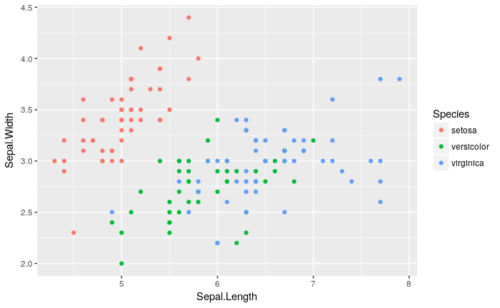

```r
ggplot(data = iris) +
  geom_point(aes(x = Sepal.Length, y = Sepal.Width, color = Species))
```

11. Gráfica de cajas de *Petal.Length* donde se distingan las distintas especies.

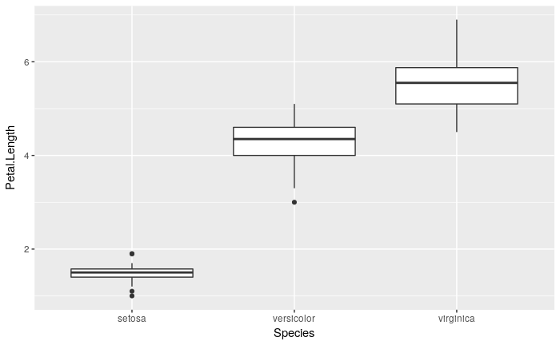

```r
ggplot(iris, aes(y = Petal.Length, x = Species)) +
  geom_boxplot()
```

### 2. Espacio de probabilidad y Variables Aleatorias

Considere un experimento que consiste en una carrera de caballos con tres caballos numerados del 1 al 3. Si no está permitido que dos o más caballos lleguen a la meta en la misma posición:

1. ¿Cuál es el espacio de resultados $\Omega$ del experimento?

$$\Omega = {123, 231, 312, 321, 213, 132}$$

```r
1/6
```

```
[1] 0.1666667
```

3. ¿Cuáles son los elementos de los eventos $A$ y $B$, respectivamente?

$$A = \{123,132,213\}$$
$$B = \{132,231\}$$

4. ¿Cuáles son los elementos del evento $A \cap B$?

$$A \cap B = 132$$

5. ¿Cuáles son los elementos del evento $A \cup B$?

$$A \cup B = \{123, 132, 313, 231\}$$

6. ¿Cuál es la probabilidad $P(B)$ de que ocurra $B$? *33%*

```r
2*(1/6)
```

```
[1] 0.3333333
```

7. Liste los valores $X(\omega)$ que toma la variable $X$ para cada uno de los elementos $\omega \in \Omega$

$$X(\omega) = \{1,2,3\}$$

8. ¿Cuál es la probabilidad de $P(X = 1)$?

```r
2*(1/6)
```

```
[1] 0.3333333
```

### 3. Probabilidad condicional

1. ¿Son $X$ y $Y$ variables independientes? *No son independientes, dado que se afectan mutuamente y a sus probabilidades.*
2. Calcule las probabilidad condicionales $P(Y|X = x)$ para $x = 1,2,3,4$

```r
print('P(X=1) para Y={0,1,2}')
```

```
[1] "P(X=1) para Y={0,1,2}"
```

```r
0.06/0.2
```

```
[1] 0.3
```

```r
0.12/0.2
```

```
[1] 0.6
```

```r
0.02/0.2
```

```
[1] 0.1
```

```r
print('P(x=2) para Y={0,1,2}')
```

```
[1] "P(x=2) para Y={0,1,2}"
```

```r
0.03/0.42
```

```
[1] 0.07142857
```

```r
0.18/0.42
```

```
[1] 0.4285714
```

```r
0.21/0.42
```

```
[1] 0.5
```

```r
print('P(x=3) para Y={0,1,2,3}')
```

```
[1] "P(x=3) para Y={0,1,2,3}"
```

```r
0.01/0.28
```

```
[1] 0.03571429
```

```r
0.09/0.28
```

```
[1] 0.3214286
```

```r
0.11/0.28
```

```
[1] 0.3928571
```

```r
0.07/0.28
```

```
[1] 0.25
```

```r
print('P(x=4) para Y={1,2,3,4}')
```

```
[1] "P(x=4) para Y={1,2,3,4}"
```

```r
0.02/0.1
```

```
[1] 0.2
```

```r
0.05/0.1
```

```
[1] 0.5
```

```r
0.02/0.1
```

```
[1] 0.2
```

```r
0.01/0.1
```

```
[1] 0.1
```

3. Verifique que $P(Y|X)$ satisface la segunda regla de probabilidad $\sum_{y=o}^4 P(Y = y|X=x) = 1$ para $x=1,2,3,4$

```r
print('P(X=1) para Y={0,1,2}')
```

```
[1] "P(X=1) para Y={0,1,2}"
```

```r
0.06/0.2 + 0.12/0.2 + 0.02/0.2
```

```
[1] 1
```

```r
print('P(x=2) para Y={0,1,2}')
```

```
[1] "P(x=2) para Y={0,1,2}"
```

```r
0.03/0.42 + 0.18/0.42 + 0.21/0.42
```

```
[1] 1
```

```r
print('P(x=3) para Y={0,1,2,3}')
```

```
[1] "P(x=3) para Y={0,1,2,3}"
```

```r
0.01/0.28 + 0.09/0.28 + 0.11/0.28 + 0.07/0.28
```

```
[1] 1
```

```r
print('P(x=4) para Y={1,2,3,4}')
```

```
[1] "P(x=4) para Y={1,2,3,4}"
```

```r
0.02/0.1 + 0.05/0.1 + 0.02/0.1 + 0.01/0.1
```

```
[1] 1
```

4. Calcule los valores esperados condicionales $E[Y|X = x]$ para $x=1,2,3,4$.

```r
print('Para X=1, Y={1,2,3,4}')
```

```
[1] "Para X=1, Y={1,2,3,4}"
```

```r
E_X1 <- sum(c(1*.12, 2*.18, 3*.09, 4*.02)); E_X1
```

```
[1] 0.83
```

```r
print('Para X=2, Y={1,2,3,4}')
```

```
[1] "Para X=2, Y={1,2,3,4}"
```

```r
E_X2 <- sum(c(1*.02, 2*.21, 3*.09, 4*.05)); E_X2
```

```
[1] 0.91
```

```r
print('Para X=3, Y={1,2,3,4}')
```

```
[1] "Para X=3, Y={1,2,3,4}"
```

```r
E_X3 <- sum(c(0, 0, 3*.07, 4*.02)); E_X3
```

```
[1] 0.29
```

```r
print('Para X=4, Y={1,2,3,4}')
```

```
[1] "Para X=4, Y={1,2,3,4}"
```

```r
E_X4 <- sum(c(0,0,0,4*.01)); E_X4
```

```
[1] 0.04
```

5. Grafique $g(x) = E[Y|X = x]$ para $x=1,2,3,4$.

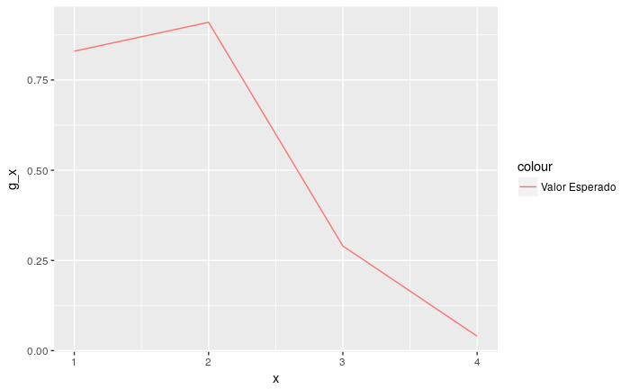

```r
df <- data.frame(x = c(1,2,3,4), g_x = c(E_X1, E_X2, E_X3, E_X4))
ggplot(df, aes(x=x,y=g_x,col="Valor Esperado")) + geom_line()
```

### 4. Bootstrap

```r
set.seed(261285)
bootstr <- rexp(n=20,rate = 1)
bootstr
```

```
 [1] 1.26562612 2.00905427 1.53277040 3.16665193 2.91957971 1.39760569 0.69141493
 [8] 1.28580721 0.02734916 0.23568531 2.94539575 0.15912479 0.47047100 1.99842617
[15] 4.75564875 0.27125596 0.21680047 0.23216209 0.40212096 2.07900431
```

```r
paste("Std Dev", sd(bootstr))
```

```
[1] "Std Dev 1.28752666879493"
```

```r
G <- cov(data.frame(bootstr)*20/19)
eigen_G <- eigen(G)
theta_hat <- eigen_G$values[1] / sum(eigen_G$values)
paste("El valor de theta_hat sí es 1: ", theta_hat)
```

```
[1] "El valor de theta_hat sí es 1:  1"
```

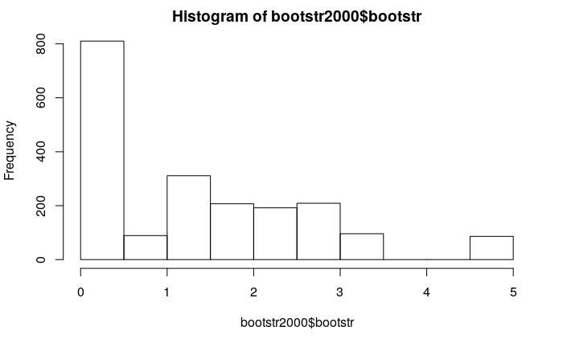

```r
set.seed(261285)
bootstr2000 <- sample_n(data.frame(bootstr), size = 2000, replace = T)
hist(bootstr2000$bootstr)
```

```r
sd(bootstr2000$bootstr)
```

```
[1] 1.226482
```

```r
pc_boot <- function(){
    muestra_boot <- sample_n(data.frame(bootstr), size = 2000, replace = T)
    G <- cov(muestra_boot) * 2000/1999
    eigen_G <- eigen(G)
    theta_hat <- eigen_G$values[1] / sum(eigen_G$values)
}
thetas_boot <- rerun(5000, pc_boot()) %>% flatten_dbl()
```

1. La siguiente tabla al repetirla 500 veces

```r
metodo <- c("Normal", "Percentiles", "BC_a")
# bca <- bcanon(x = bootstr, nboot = 2000, theta = mean)
fallo_izq <- c(-(1-1.95*sd(bootstr2000$bootstr)),
               as.double(quantile(bootstr2000$bootstr,prob=0.025)),
               bca$confpoints[1,2])
fallo_der <- c((1+.25*sd(bootstr2000$bootstr)),
               as.double(quantile(bootstr2000$bootstr,prob=0.975)),
               bca$confpoints[8,2])
cobertura <- c(100-fallo_izq[1]-fallo_der[1],
               100-fallo_izq[2]-fallo_der[2],
               100-fallo_izq[3]-fallo_der[3])
bootstrap <- data.frame(metodo, fallo_izq, fallo_der, cobertura)
bootstrap
```

| metodo | fallo_izq | fallo_der | cobertura |
| --- | --- | --- | --- |
| Normal | 1.39163925 | 1.306620 | 97.30174 |
| Percentiles | 0.02734916 | 4.755649 | 95.21700 |
| BC_a | 0.93696272 | 2.051512 | 97.01153 |

2. Realización de una gráfica de páneles mostrando los métodos normal, percentil y $BC_a$, en el eje horizontal graficando el número de intervalos de confianza ($1,2,...,500$) y en el eje vertical graficando los límites de los intervalos, utilizando la función `geom_line` para las 2 líneas, correspondientes a los límites de los intervalos inferiores y superiores.

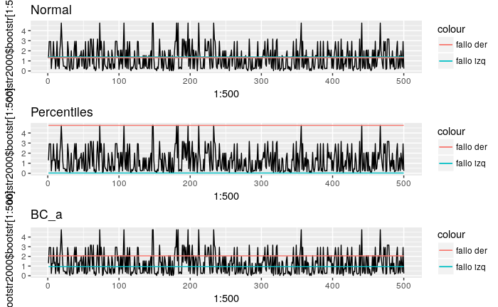

```r
plot_normal <- ggplot() +
  geom_line(aes(x=1:500,y=bootstr2000$bootstr[1:500])) +
  geom_line(aes(x=1:500,y=fallo_izq[1], col = "fallo izq")) +
  geom_line(aes(x=1:500,y=fallo_der[1], col = "fallo der")) +
  ggtitle("Normal")
plot_percentiles <- ggplot() +
  geom_line(aes(x=1:500,y=bootstr2000$bootstr[1:500])) +
  geom_line(aes(x=1:500,y=fallo_izq[2], col = "fallo izq")) +
  geom_line(aes(x=1:500,y=fallo_der[2], col = "fallo der")) +
  ggtitle("Percentiles")
plot_bca <- ggplot() +
  geom_line(aes(x=1:500,y=bootstr2000$bootstr[1:500])) +
  geom_line(aes(x=1:500,y=fallo_izq[3], col = "fallo izq")) +
  geom_line(aes(x=1:500,y=fallo_der[3], col = "fallo der")) +
  ggtitle("BC_a")
gridExtra::grid.arrange(plot_normal, plot_percentiles, plot_bca)
```